# CompanyCam_eda_assessment

## Company Cam Take Home Assessment

The dataset consists of 3 tables:

1. Users: Contains user information (user_id, signup_date, user_type)
2. Events: Contains user activity logs (event_id, user_id, event_type, event_timestamp)
3. Subscriptions: Contains details on user paid subscriptions (user_id, plan_type, start_date, end_date)

## Exploratory Data Analysis

```python
# Import necessary libraries
import pandas as pd
import matplotlib.pyplot as plt

# Load the data tables as pandas dataframes
users = pd.read_csv('user.csv')
events = pd.read_csv('event.csv')
subscriptions = pd.read_csv('subscription.csv')
```

```python
# Explore the dataframes
print(users.shape)
users.head(5)
```

```
(500, 3)
```

|  | user_id | signup_date | user_type |
| --- | --- | --- | --- |
| 0 | 1 | 2023-09-11 | Free |
| 1 | 2 | 2023-11-27 | Free |
| 2 | 3 | 2023-09-01 | Free |
| 3 | 4 | 2023-06-15 | Free |
| 4 | 5 | 2023-09-15 | Free |

```python
print(events.shape)
events.head(5)
```

```
(13333, 4)
```

|  | event_id | user_id | event_type | event_timestamp |
| --- | --- | --- | --- | --- |
| 0 | 1 | 1 | Upload Photo | 2024-02-14 |
| 1 | 2 | 1 | Invite User | 2023-11-04 |
| 2 | 3 | 1 | Login | 2023-12-22 |
| 3 | 4 | 1 | Login | 2024-01-19 |
| 4 | 5 | 1 | View Photo | 2023-10-12 |

```python
print(subscriptions.shape)
subscriptions.head(5)
```

```
(146, 5)
```

|  | subscription_id | user_id | plan_type | start_date | end_date |
| --- | --- | --- | --- | --- | --- |
| 0 | 0 | 16 | Pro | 2023-10-31 | 2024-03-09 |
| 1 | 1 | 19 | Pro | 2023-06-28 | 2024-03-14 |
| 2 | 2 | 24 | Pro | 2023-07-02 | 2024-03-08 |
| 3 | 3 | 28 | Pro | 2023-09-10 | 2024-01-21 |
| 4 | 4 | 32 | Pro | 2023-07-04 | 2024-07-06 |

```python
# User engagement summary
active_users = events['user_id'].nunique()
total_events = events.shape[0]
events_per_user = total_events / active_users
print(f"Total Active Users: {active_users}")
print(f"Total Events Logged: {total_events}")
print(f"Average Events per User: {events_per_user:.2f}")
```

```
Total Active Users: 500
Total Events Logged: 13333
Average Events per User: 26.67
```

```python
# Print the unique event types
unique_event_types = events['event_type'].unique()
print("Unique event types:", unique_event_types)
```

```
Unique event types: ['Upload Photo' 'Invite User' 'Login' 'View Photo' 'Share Photo']
```

```
Invite User     2758
Upload Photo    2677
Share Photo     2676
Login           2615
View Photo      2607
Name: event_type, dtype: int64
```

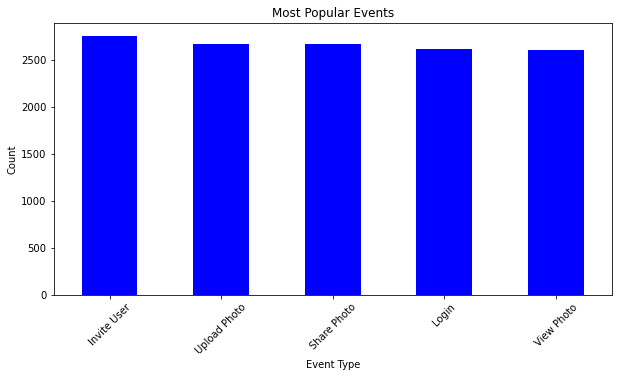

```python
# Display a plot to show which event is most popular
event_counts = events['event_type'].value_counts()
print(event_counts);

plt.figure(figsize=(10, 5))
event_counts.plot(kind='bar', color='blue')
plt.title("Most Popular Events")
plt.xlabel("Event Type")
plt.ylabel("Count")
plt.xticks(rotation=45)
plt.show()
```

```python
# Print the most popular event
most_popular_event = event_counts.idxmax()
print("Most popular event:", most_popular_event)
```

```
Most popular event: Invite User
```

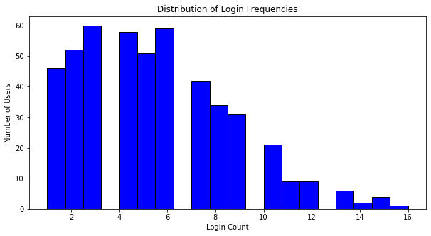

```
Average login frequency per user: 5.391752577319588
```

```python
# Distribution of login frequencies
login_counts = events[events['event_type'] == 'Login'].groupby('user_id').size()

# Plot histogram
plt.figure(figsize=(10, 5))
plt.hist(login_counts, bins=20, color='blue', edgecolor='black')
plt.title("Distribution of Login Frequencies")
plt.xlabel("Login Count")
plt.ylabel("Number of Users")
plt.show()

# Print the average login frequency
average_login_frequency = login_counts.mean()
print("Average login frequency per user:", average_login_frequency)
```

```python
# Count of logins per user
print(login_counts)
```

```
user_id
1       4
2       7
3      12
4       2
5      11
       ..
496     5
497     3
498     4
499     4
500     2
Length: 485, dtype: int64
```

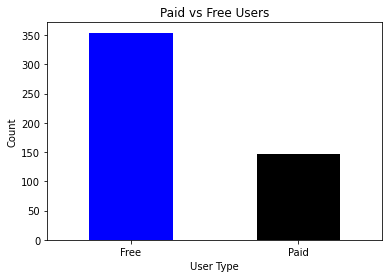

```
Free    354
Paid    146
Name: user_type, dtype: int64
```

```python
# Print number of paid vs free users
user_type_counts = users['user_type'].value_counts()
plt.figure(figsize=(6, 4))
user_type_counts.plot(kind='bar', color=['blue', 'black'])
plt.title("Paid vs Free Users")
plt.xlabel("User Type")
plt.ylabel("Count")
plt.xticks(rotation=0)
plt.show()
print(user_type_counts)
```

```python
# Print average subscription duration
subscriptions['start_date'] = pd.to_datetime(subscriptions['start_date'])
subscriptions['end_date'] = pd.to_datetime(subscriptions['end_date'])
subscriptions['subscription_duration'] = (subscriptions['end_date'] - subscriptions['start_date']).dt.days
print("Average subscription duration:", subscriptions['subscription_duration'].mean(), 'days')
```

```
Average subscription duration: 207.9931506849315 days
```

```python
#How many users remain active after signing up
active_users = users[users['user_id'].isin(events['user_id'].unique())]
num_active_users = active_users['user_id'].nunique()
print("Number of users who remain active after signing up:", num_active_users)
```

```
Number of users who remain active after signing up: 500
```

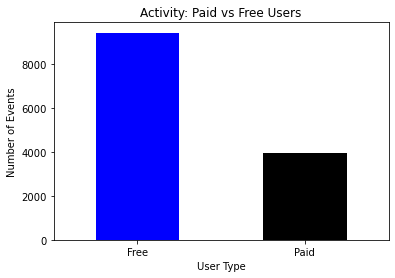

```
user_type
Free    9407
Paid    3926
Name: event_id, dtype: int64
```

```python
# Compare user activity of paid vs unpaid users
merged_data = events.merge(users, on='user_id', how='left')
activity_counts = merged_data.groupby('user_type')['event_id'].count()
plt.figure(figsize=(6, 4))
activity_counts.plot(kind='bar', color=['blue', 'black'])
plt.title("Activity: Paid vs Free Users")
plt.xlabel("User Type")
plt.ylabel("Number of Events")
plt.xticks(rotation=0)
plt.show()
print(activity_counts)
```

```python
# Average activity per user type
avg_activity_per_user_type = merged_data.groupby('user_type')['event_id'].count() / merged_data.groupby('user_type')['user_id'].nunique()
print("Average activity per user type:")
print(avg_activity_per_user_type)
```

```
Average activity per user type:
user_type
Free    26.573446
Paid    26.890411
dtype: float64
```

```python
# Print most used feature for each paid and free user
event_user_type = merged_data.groupby(['user_type', 'event_type'])['event_id'].count().reset_index()
most_used_feature = event_user_type.loc[event_user_type.groupby('user_type')['event_id'].idxmax()]
print("Most used feature by paid and free users:")
print(most_used_feature)
```

```
Most used feature by paid and free users:
  user_type   event_type  event_id
0      Free  Invite User      1962
5      Paid  Invite User       796
```

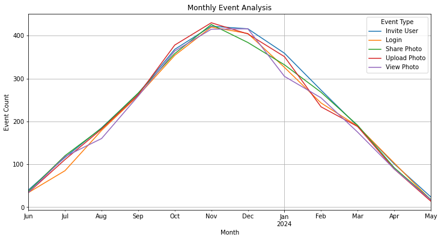

```python
# Print analysis of features month-wise
events['event_month'] = pd.to_datetime(events['event_timestamp']).dt.to_period('M')
monthly_analysis = events.groupby(['event_month', 'event_type']).size().unstack()
monthly_analysis.plot(kind='line', figsize=(12, 6))
plt.title("Monthly Event Analysis")
plt.xlabel("Month")
plt.ylabel("Event Count")
plt.legend(title="Event Type")
plt.grid()
plt.show()
```

The graph above shows that the maximum events happen in between the months of Oct to Dec. This can be attributed to contractors wanting to complete maximum tasks by year end.

## Experimentation & A/B Testing Readiness

### Proposed Experiment: Enhancing User Engagement with Emoji Reactions

To improve user engagement, I propose introducing emoji reactions (thumbs up and thumbs down) on user-generated content such as photos. This feature aims to encourage more interaction and engagement from both free and paid users. The experiment will compare engagement metrics before and after implementing this feature.

### Key Metrics

Feature Adoption Rate: Percentage of users who interact with emoji reactions.

Engagement Metrics: Changes in photo views and shares after introducing emoji reactions.

Unpaid User Engagement: Increase in interaction from free-tier users.

Paid User Engagement: Whether paid users exhibit higher engagement post-feature introduction.

Conversion Rate: Percentage of unpaid users converting to paid users after interacting with the feature.

### Success Criteria:

The experiment will be considered successful if:

There is a statistically significant increase in engagement (views, shares) after introducing emoji reactions.

Free-tier users demonstrate higher engagement with the platform.

Paid users show increased interaction with content.

The feature contributes to an increase in the conversion rate from free to paid users.

### Analysis Approach:

To evaluate the effectiveness of the feature, I will conduct an A/B test:

Randomized User Groups: Users will be randomly split into control (no emoji reactions) and treatment (with emoji reactions) groups.

Significance Testing: Conduct hypothesis testing to determine whether observed engagement differences are statistically significant.

Retention Analysis: Assess whether users continue to engage with the feature over time.

This approach will ensure a data-driven evaluation of the impact of emoji reactions on user engagement and inform further iterations of the feature.

## SQL Challenge

#### sql_retention

with last_three_signup as ( select distinct user_id from user where signup_date>=((SELECT MAX(start_date) - INTERVAL '3' month FROM subscription))),

retained_days_last_three_months as ( SELECT s.user_id, end_date-start_date as retained_days from subscription s inner join last_three_signup lts on s.user_id=lts.user_id)

select cast(avg(retained_days) as int) as retention from retained_days_last_three_months;

#### sql_top_features

SELECT event_type, COUNT(*) as event_count FROM events GROUP BY event_type ORDER BY event_count DESC LIMIT 3;

## Actionable Recommendations for Improving Product Adoption & User Retention

### Incentivized Referral Program

Since the "Invite User" feature is the most frequently used, CompanyCam should implement a referral incentive program.

Recommendation: Provide contractors with discounts, extended free trials, or exclusive features when their invitee signs up and actively engages with the platform. Similarly, offer the invited user an onboarding bonus (e.g., a temporary free trial of premium features) to encourage usage.

### Engagement-Driven Free-to-Paid Conversion Strategy

Free-tier users need more motivation to explore CompanyCam’s premium features.

Recommendation: Offer limited-time access to premium tools based on user activity (e.g., completing a certain number of actions unlocks a free trial). Additionally, introduce personalized feature recommendations through in-app nudges based on user behavior.

### Subscription Retention & Renewal Optimization

With an average subscription duration of 208 days, improving long-term retention will be key to revenue growth.

Recommendation: Implement automated renewal reminders and exclusive retention perks (e.g., discounted long-term plans, personalized analytics, or priority support) to keep paying users engaged beyond their current lifecycle.

##### These strategies will increase user adoption, improve engagement, and drive higher subscription conversions. Let me know if you need further refinements!